# Getting familiar with R

## Aim of this worksheet

After completing this worksheet, you should feel comfortable typing commands into the R console and into an [R Markdown](http://rmarkdown.rstudio.com/) document. In particular, you should know how to use values, variables, and functions, how to install and load packages, and how to use the built-in help for R and its packages.

## Values

R lets you store several different kinds of *values*. These values are the information that we actually want to do something with.

One kind of value is a number. Notice that typing this number, either in an R Markdown document or at the console, causes the same number to be printed as output.

```r
42
```

```
## [1] 42
```

1. Create a numeric value that has a decimal point:

```r
42.0
```

```
## [1] 42
```

Of course numbers can be added together (with `+`), subtracted (with `-`), multiplied (with `*`), and divided (with `/`), along with other arithmetical operations. Let’s add two numbers, which will produce a new number.

```r
2 + 2
```

```
## [1] 4
```

2. Add two lines, one that multiplies two numbers, and another that subtracts two numbers.

```r
# Multiplying two numbers
2*2
```

```
## [1] 4
```

```r
# Subtracting two numbers
2-2
```

```
## [1] 0
```

Another important kind of value contains text. In most most programming languages these are called strings, but in R you might also hear them called character vectors. To create a string, include some characters in between quotation marks `""`. (Single quotation marks work too, but in general use double-quotation marks as a matter of style.) For instance:

```r
"Hello, beginning R programmer. Greetings!"
```

```
## [1] "Hello, beginning R programmer. Greetings!"
```

3. Create a string with your own message.

```r
"Hello, my name is Shakil."
```

```
## [1] "Hello, my name is Shakil."
```

Character vectors can’t be added together with `+`. But they can be joined together with the `paste()` function.

```r
paste("Hello", "everybody")
```

```
## [1] "Hello everybody"
```

4. Mimic the example above and paste three strings together.

```r
paste("Hello", "everybody","my name is Shakil")
```

```
## [1] "Hello everybody my name is Shakil"
```

5. Now explain in a sentence what happened.

> It concatenatres the strings and adds white space before the string after the comma (,)

Another very important kind of value are logical values. There are only two of them: `TRUE` and `FALSE`.

```r
# This is true
TRUE
```

```
## [1] TRUE
```

```r
# This is false
FALSE
```

```
## [1] FALSE
```

Notice that in the block above, the `#` character starts a *comment*. That means that from that point on, R will ignore whatever is on that line until a new line begins.

Logical values are useful when we want to compare values to one another. For instance, we can compare two numbers to one another.

```r
2 < 3
```

```
## [1] TRUE
```

```r
2 > 3
```

```
## [1] FALSE
```

```r
2 == 3
```

```
## [1] FALSE
```

6. What do each of those comparison operators do? (Note the double equal sign: `==`.)

> The ‘<’ checks if a quantity is less than another quantity The ‘>’ checks if a quantity is more than another quantity The ‘==’ checks if a quantity is equal to another quantity
7. Create your own comparisons between numeric values. See if you can create a comparison between character vectors.

```r
a = 2
b = 3
c = 4
d = 2

# Less than
a < b
```

```
## [1] TRUE
```

```r
# More than
b > c
```

```
## [1] FALSE
```

```r
# Equal to
a == d
```

```
## [1] TRUE
```

R has a special kind of value: the missing value. This is represented by `NA`.

```r
NA
```

```
## [1] NA
```

Try adding `2 + NA`.

```r
2 + NA
```

```
## [1] NA
```

8. Does that answer make sense? Why or why not?

> Yes, its N/A, because you cannot add 2 to a value which is N/A

## Variables

We wouldn’t be able to get very far if we only used values. We also need a place to store them, a way of writing them to the computer’s memory. We can do that by *assignment* to a variable. Assignment has three parts: it has the name of a variable (which cannot contain spaces), an assignment operator, and a value that will be assigned. Most programming languages use a rinky-dink `=` for assignment, which works in R too. But R is awesome because the assignment operator is `<-`, a lovely little arrow which tells you that the value goes into the variable. For example:

```r
number <- 42
```

Notice that nothing was printed as output when we did that. But now we can just type `number` and get the value which is stored in the variable. (For the curious: when we just type something at the R console, without doing something particular with it, R prints the result of that expression.)

```r
number
```

```
## [1] 42
```

It works with character vectors too.

```r
computer_name <- "HAL 9000"
```

Again no output when we save a value to a variable, but this prints the value stored in the variable.

```r
computer_name
```

```
## [1] "HAL 9000"
```

9. In the assignment above, what is the name of the variable? What is the assignment operator? What is the value assigned to the variable?

> Variable=‘computer_name’, Assignment Operator=‘<-’, Value=“HAL 9000”

Notice that we can use variables any place that we used to use values. For example:

```r
x <- 2
y <- 5
x * y
```

```
## [1] 10
```

```r
x + 9
```

```
## [1] 11
```

10. Explain in your own words what just happened.

> A variable named ‘x’ got assigned the value 2 A variable named ‘y’ got assigned the value 5 The ‘x’ and ‘y’ variables got multiplied The variable ‘x’ got the value 9 added to it
11. Now create three assignments. Assign two different numbers to two different variables. Then do some arithmetic with those two variables, and assign the results to a variable. Try printing out that variable.

```r
x <- 10
y <- 5
z <- x/y
z
```

```
## [1] 2
```

Here is some code that might be tricky to predict, if you don’t have the right mental model of what is happening.

```r
a <- 10
b <- 20
a <- b
# print(a)
```

12. What value will the variable `a` hold? Predict your answer, then uncomment the line that prints `a` and run the code. What is the value stored in `a` by the end? Explain why you were right or wrong.
> 20. I was right. This is because it is assigned the variable ‘b’, whose value is 20

## Vectors

Variables are better than just values, but we still need to be able to store multiple values. If we have to store each value in its own variable, then we are going to need a lot of variables. In R every value is actually a vector. That means it can store more more than one value.

Notice the funny output after running this line:

```r
"Some words"
```

```
## [1] "Some words"
```

What does the `[1]` in the output mean? It means that the value has one item inside it. We can test that with the `length()` function

```r
length("Some words")
```

```
## [1] 1
```

Sure enough, the length is `1`: R is counting the number of items, not the number of words or characters. (For the bold: compare the output of `nchar("Some words")`.)

That would seem to imply that we can add multiple items (or values) inside a vector. R lets us do that with the `c()` (for “combine”) function.

```r
many <- c(1, 5, 2, 3, 7)
many
```

```
## [1] 1 5 2 3 7
```

13. What is the length of the vector stored in `many`?

```r
length(many)
```

```
## [1] 5
```

Let’s try multiplying `many` by `2`:

```r
many * 2
```

```
## [1]  2 10  4  6 14
```

14. What happened?

> every item in ‘many’ was multiplied by 2
15. What happens when you add `2` to `many`?

```r
many + 2
```

```
## [1] 3 7 4 5 9
```

> every value in ‘many’ has the value 2 added to it
16. Can you create a variable containing several historical names as a character vector?

```r
historical_names <- c("Muhammad (SAW)", "Isa (AS)", "Musa (AS)", "Ibrahim (AS)", "Nuh (AS)")
historical_names
```

```
## [1] "Muhammad (SAW)" "Isa (AS)"       "Musa (AS)"      "Ibrahim (AS)"
## [5] "Nuh (AS)"
```

17. Hard question: what is happening here? Why does R give you a warning message?

```r
c(1, 2, 3, 4, 5) + c(10, 20)
```

```
## Warning in c(1, 2, 3, 4, 5) + c(10, 20): longer object length is not a multiple
## of shorter object length
```

```
## [1] 11 22 13 24 15
```

## Built-in functions

Wouldn’t it be nice to be able to do something with those vectors of data? Let’s take some made up data: the price of books that you or I have bought recently.

```r
book_prices <- c(19.99, 25.78, 5.33, 45.00, 22.45, 21.23)
```

We can find the total amount that I spent using the `sum()` function. Notice that the `sum()` function, like the `c()` function earlier, is called by using the name of the function followed by parentheses. Things can go inside the parentheses to make the function do something useful. Those things are called arguments.

```r
sum(book_prices)
```

```
## [1] 139.78
```

18. Try finding the average price of the books (using `mean()`) and the median price of the books (using `median()`).

```r
mean(book_prices)
```

```
## [1] 23.29667
```

```r
median(book_prices)
```

```
## [1] 21.84
```

19. Can you figure out how to find the most expensive book (hint: the book with the maximum price) and the least expensive book (hint: the book with the minimum price)?

```r
max(book_prices)
```

```
## [1] 45
```

```r
min(book_prices)
```

```
## [1] 5.33
```

20. Hard question: what is happening here?

```r
book_prices >= mean(book_prices)
```

```
## [1] FALSE  TRUE FALSE  TRUE FALSE FALSE
```

> Checking each book price in ‘book_prices’, to see if it costs more/less than the mean of the book prices

## Using the documentation

Let’s try a different set of book prices. This time, we have a vector of book prices, but there are some books for which we don’t know how much we paid. Those are the `NA` values.

```r
more_books <- c(19.99, NA, 25.78, 5.33, NA, 45.00, 22.45, NA, 21.23)
```

21. How many books did we buy? (Hint: what is the length of the vector?)

```r
length(more_books)
```

```
## [1] 9
```

Let’s try finding the total using `sum()`.

```r
sum(more_books)
```

```
## [1] NA
```

22. That wasn’t very helpful. Why did R give us an answer of `NA`?

> because of the N/A values

We need to find a way to get the value of the books that we know about. This is an option to the `sum()` function. If you know the name of a function, you can search for it by typing a question mark followed without a space by the name of the function. For example, `?sum`. Look up the `sum()` function’s documentation by typing that command in the R console. Don’t keep it in your RMarkdown file. Read at least the “Arguments” and the “Examples” section.

23. How can you get the sum for the values which aren’t missing?

```r
sum(more_books, na.rm = TRUE)
```

```
## [1] 139.78
```

Look up the documentation these functions: `?mean`, `?max`, `?min`.

24. Use those functions on the vector with missing values.

```r
mean(more_books, na.rm = TRUE)
```

```
## [1] 23.29667
```

```r
max(more_books, na.rm = TRUE)
```

```
## [1] 45
```

```r
min(more_books, na.rm = TRUE)
```

```
## [1] 5.33
```

## Data frames and loading packages

R has a lot of functionality built in for working with data, especially compared to other languages. For instance, the functions `mean()`, `median()` and so forth are not built in to other languages. But most of the time in R, we won’t be working just with the language. We will also be using R packages, which contain functions and data that users have contributed to the R ecosystem.

Let’s start by loading the tibble package. This is a package that helps us work with data frames. It is quite possible that you do not yet have this package installed. If so, run `install.packages("tibble")` at the R console, and it will be installed for you. This package will come from CRAN, the central repository where R packages are published.

```r
library(tibble)
```

Sometimes we want to get packages that haven’t been published, but which are nevertheless available on GitHub. To do that we need to install the remotes package, and then install whatever package we want from GitHub. At the R console, run `install.packages("remotes")`. Then run `remotes::install_github("ropensci/historydata")`. If everything works successfull you should be able to run the following code to load the historydata package.

```r
library(historydata)
```

We are historians, and we want to work with complex data. Another reason R is awesome is that it includes a kind of data structure called *data frames*. Think of a data frame as basically a spreadsheet. It is tabular data, and the columns can contain any kind of data available in R, such as character vectors, numeric vectors, or logical vectors. R has some sample data built in, but let’s use some historical data from the [historydata](https://github.com/ropensci/historydata/) package.

We don’t know what is in the historydata package, so let’s look at its help. Run this command: `help(package = "historydata")`. (In general, you don’t want to include commands like `help()` or `install.packages()` in these worksheets. Just run them at the R console.)

25. Let’s use the data in the `paulist_missions` data frame. According to the package documentation, what is in this data frame?

> Missions carried out on churches in the states, their locations and start/end date

We can print it by using the name of the variable.

```r
paulist_missions
```

```
## # A tibble: 841 x 17
##    mission_number church city  state date_start date_end    year decade
##             <int> <chr>  <chr> <chr> <date>     <date>     <dbl> <chr>
##  1              1 St. J~ New ~ NY    1851-04-06 1851-04-20  1851 1850s
##  2              2 St. M~ Lore~ PA    1851-04-27 1851-05-11  1851 1850s
##  3              3 St. M~ Holl~ PA    1851-05-18 1851-05-28  1851 1850s
##  4              4 Churc~ John~ PA    1851-05-31 1851-06-08  1851 1850s
##  5              5 St. P~ New ~ NY    1851-09-28 1851-10-12  1851 1850s
##  6              6 St. P~ New ~ NY    1851-10-19 1851-11-03  1851 1850s
##  7              7 St. P~ Erie  PA    1851-11-17 1851-11-28  1851 1850s
##  8              8 St. P~ Cuss~ PA    1851-12-01 1851-12-08  1851 1850s
##  9              9 St. V~ Youn~ PA    1851-12-10 1851-12-19  1851 1850s
## 10             10 St. P~ Sara~ NY    1852-01-11 1852-01-22  1852 1850s
## # ... with 831 more rows, and 9 more variables: duration_days <int>,
## #   duration_weeks <ord>, confessions <int>, converts <int>, order <chr>,
## #   lat <dbl>, long <dbl>, volume <int>, page <int>
```

The `head()` function just gives us the first few items in a vector or data frame. It’s useful if you don’t want to print out a big long dataset.

```r
head(paulist_missions)
```

```
## # A tibble: 6 x 17
##   mission_number church city  state date_start date_end    year decade
##            <int> <chr>  <chr> <chr> <date>     <date>     <dbl> <chr>
## 1              1 St. J~ New ~ NY    1851-04-06 1851-04-20  1851 1850s
## 2              2 St. M~ Lore~ PA    1851-04-27 1851-05-11  1851 1850s
## 3              3 St. M~ Holl~ PA    1851-05-18 1851-05-28  1851 1850s
## 4              4 Churc~ John~ PA    1851-05-31 1851-06-08  1851 1850s
## 5              5 St. P~ New ~ NY    1851-09-28 1851-10-12  1851 1850s
## 6              6 St. P~ New ~ NY    1851-10-19 1851-11-03  1851 1850s
## # ... with 9 more variables: duration_days <int>, duration_weeks <ord>,
## #   confessions <int>, converts <int>, order <chr>, lat <dbl>, long <dbl>,
## #   volume <int>, page <int>
```

The `str()` function is helpful for all R objects. It shows us the structure of data. Look up the documentation for it, and then run it on `paulist_missions`.

```r
str(paulist_missions)
```

```
## tibble [841 x 17] (S3: tbl_df/tbl/data.frame)
##  $ mission_number: int [1:841] 1 2 3 4 5 6 7 8 9 10 ...
##  $ church        : chr [1:841] "St. Joseph's Church" "St. Michael's Church" "St. Mary's Church" "Church of St. John Evangelist" ...
##  $ city          : chr [1:841] "New York" "Loretto" "Hollidaysburg" "Johnstown" ...
##  $ state         : chr [1:841] "NY" "PA" "PA" "PA" ...
##  $ date_start    : Date[1:841], format: "1851-04-06" "1851-04-27" ...
##  $ date_end      : Date[1:841], format: "1851-04-20" "1851-05-11" ...
##  $ year          : num [1:841] 1851 1851 1851 1851 1851 ...
##  $ decade        : chr [1:841] "1850s" "1850s" "1850s" "1850s" ...
##  $ duration_days : int [1:841] 14 14 10 8 14 15 11 7 9 11 ...
##  $ duration_weeks: Ord.factor w/ 4 levels "1 week or less"<..: 2 2 2 2 2 3 2 1 2 2 ...
##  $ confessions   : int [1:841] 6000 1700 1000 1000 4000 7000 1000 270 1000 600 ...
##  $ converts      : int [1:841] 0 0 0 0 0 0 0 0 0 3 ...
##  $ order         : chr [1:841] "Redemptorist" "Redemptorist" "Redemptorist" "Redemptorist" ...
##  $ lat           : num [1:841] 40.7 40.5 40.4 40.3 40.7 ...
##  $ long          : num [1:841] -74 -78.6 -78.4 -78.9 -74 ...
##  $ volume        : int [1:841] 1 1 1 1 1 1 1 1 1 1 ...
##  $ page          : int [1:841] 1 6 11 12 15 18 20 22 22 23 ...
```

27. Also try the `glimpse()` function. Unlike `str()`, which is built in to R, `glimpse()` is a part of an add-on package.

```r
glimpse(paulist_missions)
```

```
## Rows: 841
## Columns: 17
## $ mission_number <int> 1, 2, 3, 4, 5, 6, 7, 8, 9, 10, 11, 12, 13, 14, 15, 1...
## $ church         <chr> "St. Joseph's Church", "St. Michael's Church", "St. ...
## $ city           <chr> "New York", "Loretto", "Hollidaysburg", "Johnstown",...
## $ state          <chr> "NY", "PA", "PA", "PA", "NY", "NY", "PA", "PA", "PA"...
## $ date_start     <date> 1851-04-06, 1851-04-27, 1851-05-18, 1851-05-31, 185...
## $ date_end       <date> 1851-04-20, 1851-05-11, 1851-05-28, 1851-06-08, 185...
## $ year           <dbl> 1851, 1851, 1851, 1851, 1851, 1851, 1851, 1851, 1851...
## $ decade         <chr> "1850s", "1850s", "1850s", "1850s", "1850s", "1850s"...
## $ duration_days  <int> 14, 14, 10, 8, 14, 15, 11, 7, 9, 11, 28, 14, 14, 14,...
## $ duration_weeks <ord> 2 weeks or less, 2 weeks or less, 2 weeks or less, 2...
## $ confessions    <int> 6000, 1700, 1000, 1000, 4000, 7000, 1000, 270, 1000,...
## $ converts       <int> 0, 0, 0, 0, 0, 0, 0, 0, 0, 3, 0, 0, 0, 0, 0, 0, 3, 0...
## $ order          <chr> "Redemptorist", "Redemptorist", "Redemptorist", "Red...
## $ lat            <dbl> 40.71435, 40.50313, 40.42729, 40.32674, 40.71435, 40...
## $ long           <dbl> -74.00597, -78.63030, -78.38890, -78.92197, -74.0059...
## $ volume         <int> 1, 1, 1, 1, 1, 1, 1, 1, 1, 1, 1, 1, 1, 1, 1, 1, 1, 1...
## $ page           <int> 1, 6, 11, 12, 15, 18, 20, 22, 22, 23, 27, 28, 31, 33...
```

28. Bonus: which package does the `glimpse()` function come from?

> dplyr package

We will get into subsetting data in more detail later. But for now, notice that we can get just one of the colums using the `$` operator. For example:

```r
head(paulist_missions$city, 20)
```

```
##  [1] "New York"      "Loretto"       "Hollidaysburg" "Johnstown"
##  [5] "New York"      "New York"      "Erie"          "Cussewago"
##  [9] "Youngstown"    "Saratoga"      "Troy"          "Albany"
## [13] "Detroit"       "Philadelphia"  "Philadelphia"  "Cohoes"
## [17] "Wheeling"      "Cincinnati"    "Louisville"    "Albany"
```

29. Can you print the first 20 numbers of converts? of confessions?

```r
paulist_missions$converts
```

```
##   [1]  0  0  0  0  0  0  0  0  0  3  0  0  0  0  0  0  3  0  3  3  3  3  3  0  0
##  [26]  0  0  0  0  7 10 16  3  3  2  0  2  2  0  0  0  0  3  0  3  3  0  3  2  0
##  [51] 20  3  0  0  0  1  3  0  9  0  0  7  0  3  3  3  3  1  0  0 20  0  0  0  2
##  [76]  0  0  1  5  2  1  0  0  3  0  3  5 15  0  0  0  2  1  1  5  4  1  2 50  6
## [101]  6  3  5  0  0  3  3  3  0  0  0  5  5  0  1  1 10  0  4  0  0  3  5  1  0
## [126]  1  0  1  2  1  0  0  2  2  0  4  0  7  0  0  3  1  1  8  3  0  6  1  0 10
## [151]  1  0  2  1  4  3  1  3  3 11  0  1  1 13  0  0  0  0  0  0  0  0  9  2  0
## [176]  2 10  2  2  0  0  1  0  0  8  2  0 22  7  4  4 18  2  1 12  8  2  3  6  2
## [201]  0  1 12  6  6  8  6  6  6  7  1 13  2  9  5  0  2  5  2  3  1  1  1  1  6
## [226]  6 12  6 10 29  2 14  3  7  0 17  3 13  6  8  8  2 11  3  3  4  2  3  1  0
## [251]  2  1  1  3  1  2  6  5  7  3  5  0 15 25  3  0  5  7  0  8  0  4  1  4  0
## [276]  7  2  5  2  6  6  0 11  1  2  1  8  1  1  7  3  1  0  1  1  0  0  0  0  1
## [301]  3  0  0  5  0  0  0  0  8  5  0  4  0  3  0  0  0  0  0  4  0  2  0  0  2
## [326]  7  0  9  3  0  7  6  0 18  5  5  2  1  2  1  3  1  0  0  0  2  0  3  4  0
## [351]  0  0  0  3  0  0 25  1  3  0  1  0  0  0  1  2  0  1  1  1  1 12  1  7  0
```

[output cut: 19 more lines]

```r
paulist_missions$confessions
```

```
##   [1]  6000  1700  1000  1000  4000  7000  1000   270  1000   600  3100  4000
##  [13]  3000  3000  1700  1400  1250  5000  2000  4500   620  2300  2550  4500
##  [25]   320   950  1200   550  7800   500   330  4000  3000  1300  1300  2000
##  [37]  1700  1500  1500  1300  2700   500  2500  4400  2800  1000  1400   600
##  [49]   350   700  7600  3000  1100  3300  4000  2800  1350   400   520   900
##  [61]   210   700  1700  2700  2500   190   210   170   750   600  3100  2200
##  [73]   800  1900   800  1950  3000   920  2050  1400  1100   277   840  1008
##  [85]   970   800  1073  5700  4430  2000  1450   430   575   450   910  2060
##  [97]   570  1135  7250  2600  8450  1950  3500  1570   800  1250  2800  2270
## [109]  1230   810   925  2640  1900  2150  1000  1100  6950  4550  1002  2900
## [121]  1900  1980  1850   950  4000   370   700  1150  1000  6800  2400  2500
## [133]  2500   900  2875  5636  3500  2100  1500  3000  2600  2000   710  2600
## [145]  2500  1300  4500  1400   567  2800  1100   700  1080   750   730   800
## [157]  1200   700  2100  2551  1200  1600  1200  1600  1400  2600   721  1261
## [169]  1400  2000  1300  1800  1500  1500  2150  1600  6600  2780  3000  5500
```

[output cut: 56 more lines]

30. What was the mean number of converts? the maximum?

```r
mean_conv <- mean(paulist_missions$converts)
mean_conv
```

```
## [1] 2.507729
```

```r
max_conv <- max(paulist_missions$converts)
max_conv
```

```
## [1] 50
```

31. Bonus: what was the ratio between confessions and conversions?

```r
mean_conv1 <- mean(paulist_missions$confessions, na.rm = TRUE)
mean_conv2 <- mean(paulist_missions$conversions, na.rm = TRUE)
ratio <- mean_conv2/mean_conv1
ratio
```

```
## [1] NA
```

## Plots

And for fun, let’s make a scatter plot of the number of confessions versus the number of conversions.

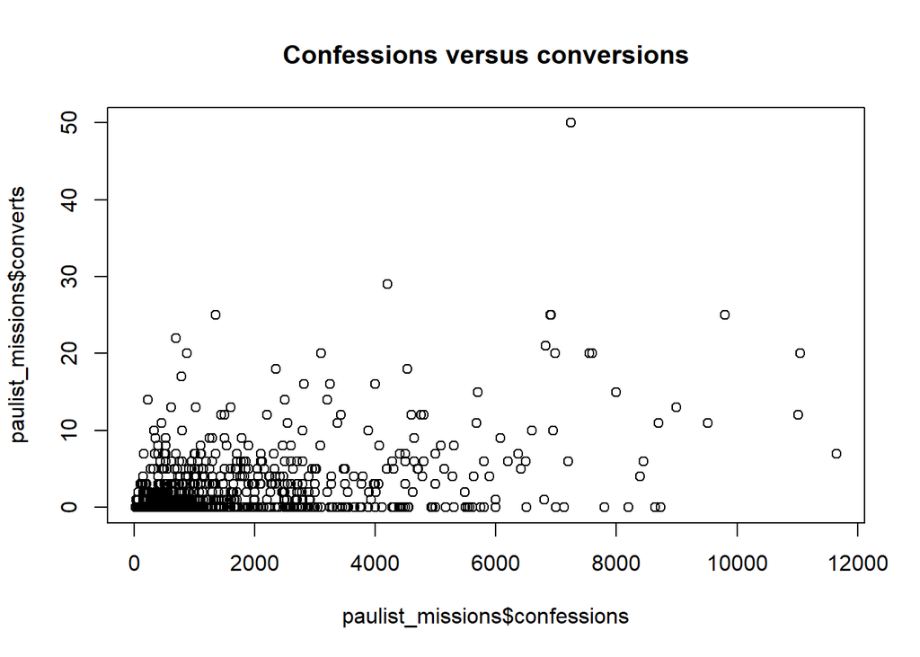

```r
plot(paulist_missions$confessions, paulist_missions$converts)
title("Confessions versus conversions")
```

32. What might you be able to learn from this plot?

```r
library(historydata)
summary(cars)
```

```
##      speed           dist
##  Min.   : 4.0   Min.   :  2.00
##  1st Qu.:12.0   1st Qu.: 26.00
##  Median :15.0   Median : 36.00
##  Mean   :15.4   Mean   : 42.98
##  3rd Qu.:19.0   3rd Qu.: 56.00
##  Max.   :25.0   Max.   :120.00
```

```r
summary(catholic_dioceses)
```

```
##    diocese              rite                lat             long
##  Length:425         Length:425         Min.   :14.91   Min.   :-157.86
##  Class :character   Class :character   1st Qu.:27.80   1st Qu.:-102.21
##  Mode  :character   Mode  :character   Median :39.29   Median : -93.75
##                                        Mean   :36.31   Mean   : -92.74
##                                        3rd Qu.:44.05   3rd Qu.: -79.38
##                                        Max.   :64.84   Max.   : -52.71
##           event          date
##  erected     :355   Min.   :1511-08-11 00:00:00
##  metropolitan: 70   1st Qu.:1871-09-22 00:00:00
##                     Median :1930-01-31 00:00:00
##                     Mean   :1912-09-05 20:33:20
##                     3rd Qu.:1964-12-21 00:00:00
##                     Max.   :2083-10-19 00:00:00
```

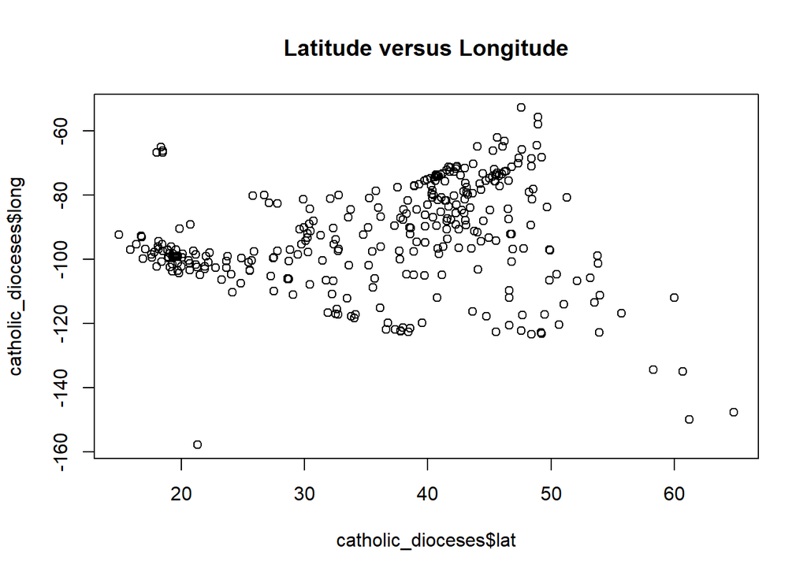

```r
plot(catholic_dioceses$lat, catholic_dioceses$long)
title("Latitude versus Longitude")
```